# Dados de Galileo

Jorge de la Vega

23/08/2021

## Estimando probabilidades vía simulación

El problema de los dados de Galileo visto la semana pasada considera el lanzamiento de tres dados, y se solicita compararlas vía simulación.

El problema teórico no es difícil. Si consideramos las ternas $(X_1,X_2,X_3)$, cada $X_i$ representando un dado, entonces podemos calcular fácilmente las probabilidades para la suma $Y=X_1+X_2+X_3$.

El número de posibles valores de $Y$ tiene rango $\{3,\ldots,18\}$ Hay $6^3=216$ posibles ternas diferentes, de las cuales 25 suman 9 y 27 suman 10. Entonces si $p_9=P(Y=9)$ y $p_{10}=P(Y=10)$, tenemos

```r
Omega <- expand.grid(dado1 = 1:6, dado2 = 1:6, dado3 = 1:6)
head(Omega)  # muestra los primeros 6 resultados de Omega.
```

```
  dado1 dado2 dado3
1     1     1     1
2     2     1     1
3     3     1     1
4     4     1     1
5     5     1     1
6     6     1     1
```

```r
which(apply(Omega,1,sum) == 9)  # ¿Cuáles casos suman 9?
```

```
 [1]  12  17  22  27  32  42  47  52  57  62  67  77  82  87  92  97 112 117 122
[20] 127 147 152 157 182 187
```

```r
which(apply(Omega,1,sum) == 10) # ¿Cuáles casos suman 10?
```

```
 [1]  18  23  28  33  48  53  58  63  68  78  83  88  93  98 103 113 118 123 128
[20] 133 148 153 158 163 183 188 193
```

```r
p9 <- (length(which(apply(Omega,1,sum) == 9))/nrow(Omega))
p10 <- (length(which(apply(Omega,1,sum) == 10))/nrow(Omega))
```

Claramente, $p_{10} = 27/216$ es mayor que $p_9 = 25/216$. ¿Se corrobora el resultado con simulación?

La siguiente función genera una muestra de tamaño $n$ de la suma de los tres dados.

```r
sumatresdados <- function(n,semilla = 1){
     set.seed = semilla
     x <- numeric(n)
     probas <- c(1/5,1/6,1/6,1/6,1/6,2/15) #dado desbalanceado
     for(i in 1:n)
        x[i] <- sum(sample(1:6,3,replace = T,prob = probas))
     x
}
```

A partir de estas muestras, podemos calcular las trayectorias del estimador $\hat{p}_k(n) = \frac{\sum_{i=1}^nI(Y_i=k)}{n}$. Por ejemplo, con $n=10,000$ lanzamientos

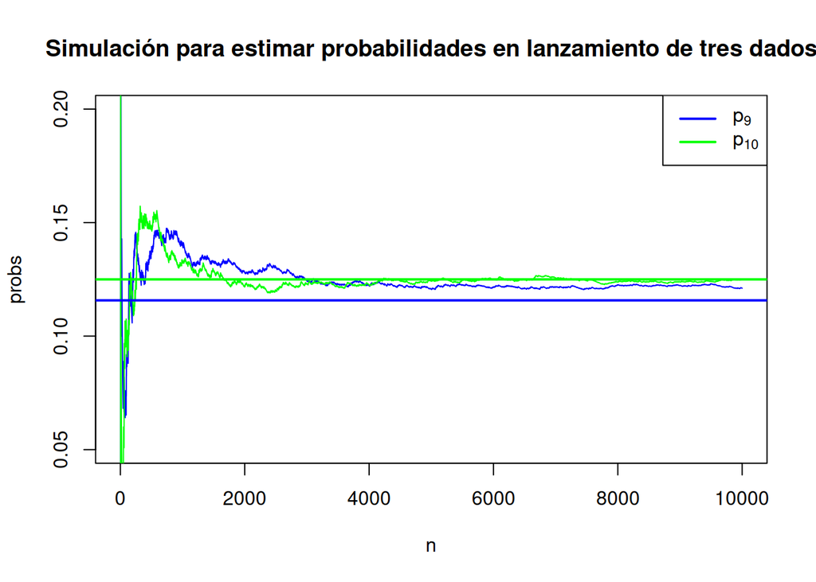

```r
n <- 10000
phat9 <- cumsum(sumatresdados(n) == 9)/(1:n)
phat10 <- cumsum(sumatresdados(n) == 10)/(1:n)

# Grafica los resultados
plot(phat9,type = "l", col = "blue", ylim = c(0.05, 0.2), ylab = "probs", xlab="n",
     main="Simulación para estimar probabilidades en lanzamiento de tres dados")
lines(phat10, col = "green")
abline(h=c(p9,p10), col = c("blue","green"),lwd=2)
legend("topright",legend = c(expression(p[9]),expression(p[10])),
       col = c("blue","green"),lwd = c(2,2))
```

En este caso, como en el caso de las agujas de Buffon, podemos calcular intervalos de confianza para nuestro estimador, ya que estamos estimando proporciones. Podemos definir la variable $X_i(n)=$ número de casos en $n$ lanzamientos que suman $i$. Entonces $X_i(n) \sim Bin(n,p_i)$, donde $p_i$ es la probabilidad que corresponde a una suma de $i$. El resto del ejercicio es idéntico al que ya vimos.